# Text Prediction App Presentation

24 March 2017

## Introduction

- Purpose: predict most likely next word in a phrase or sequence
- Available on https://jraniero.shinyapps.io/TextPredictor/
- Code (app and preprocessing) on https://github.com/jraniero/capstoneproject
- Algorithm based on Good - Turing Frequency Estimation
- Algorithm favours matches of longer n-grams

## Using the app

- Input a few words or a phrase under the "phrase" field
- Click on "Predict"
- The App will then show a histogram and wordcloud of the most likely word to follow

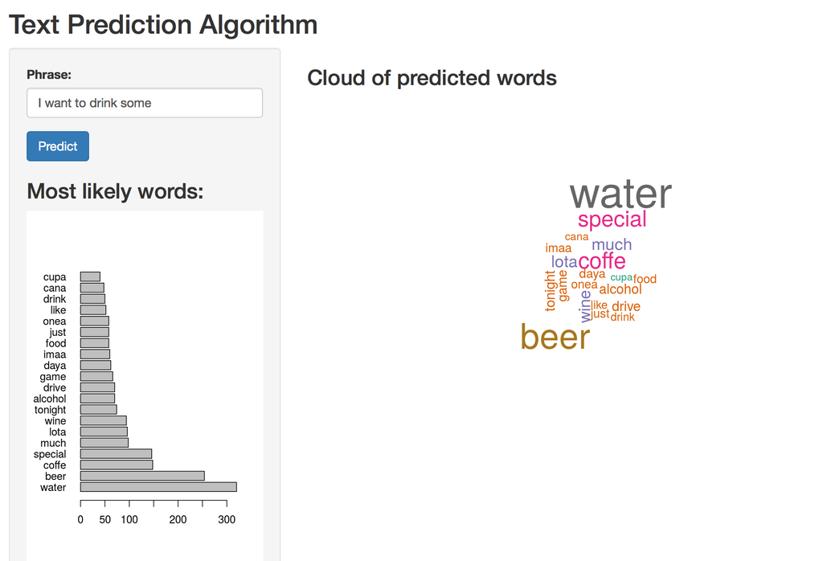

## Algorithm description

- Usage of prestored n-gram dictionnary of up to 5 words, with their frequency
- First preprocess user input (to lowercase, remove stopwords, numbers…)
- Looks for matches in the n-gram dictionnary, each match is scored
- Score is calculated as: frequency times the length of n-gram
- Higher score to longer n-grams
- Return the last words of each of the n-grams with highest score
- Fast: provides results in a few seconds

## Algorithm accuracy tests

- The algorithm was tested against a test set of 4000 phrases
- Exact matches 251, mismatches3731 not exact predictions.
- Exact prediction rate of 6.30% (note rate does not account for synonym match)
- Given that there are 94212 unique words in dictionnary, probability of randomly picking right word is 0.001%
- Algorithm outperforms random selection, even without considering synonym matches
- Test code: https://github.com/jraniero/capstoneproject/blob/master/test_perf.R